# Introduction to using R package: `spBFA`

## Assessing model convergence

Before analyzing the raw MCMC samples from our model we want to verify that there are no convergence issues. We begin by loading the `coda` package.

```r
library(coda)
```

Then we convert the raw `spBFA` MCMC objects to `coda` package `mcmc` objects. We look at $\sigma^2(\mathbf{s}_1)$ only for learning purposes.

```r
Sigma2_1 <- as.mcmc(reg.bfa_sp$sigma2[, 1])
```

We begin by checking traceplots of the parameter.

[figure not shown]

From the figure, it is clear that the traceplots exhibit some poor behavior. However, these traceplots are nicely behaved considering the number of iterations the MCMC sampler ran. The traceplots demonstrate that the parameters have converged to their stationary distribution, but still need more samples to rid themselves of autocorrelation. Finally, we present the corresponding test statistics from the Geweke diagnostic test.

[output not shown]

Since the test statistic is not terribly large in the absolute value there is not strong evidence that our model did not converge.

## Compute diagnostics

The `diagnostics` function in the `spBFA` package can be used to calculate various diagnostic metrics. The function takes in the `spBFA` regression object.

```r
Diags <- spBFA::diagnostics(reg.bfa_sp, diags = c("dic", "dinf", "waic"), keepDeviance = TRUE)
```

```
## Calculating Log-Lik: 0%.. 25%.. 50%.. 75%.. 100%.. Done!
## Calculating PPD: 0%.. 25%.. 50%.. 75%.. 100%.. Done!
```

The `diagnostics` function calculates diagnostics that depend on both the log-likelihood and posterior predictive distribution. So, if any of these diagnostics are specified, one or both of these must be sampled from. The `keepDeviance` and `keepPPD` indicate whether or not these distributions should be saved for the user. We indicate that we would like the output to be saved for the log-likelihood (i.e., deviance). We explore the output by looking at the traceplot of the deviance.

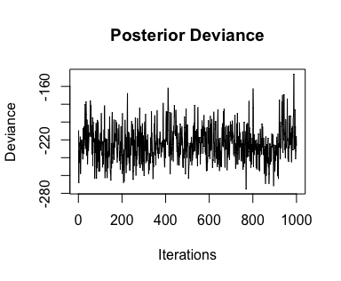

```r
Deviance <- as.mcmc(Diags$deviance)
traceplot(Deviance, ylab = "Deviance", main = "Posterior Deviance")
```

This distribution has possible convergence issues, however this is not concerning given the number of MCMC iterations run.

```r
print(Diags)
```

```
##       dic        pd
## -100.5787  124.2647
```

```
##        p        g     dinf
## 214.9629  66.5324 281.4953
```

```
##      waic    p_waic      lppd  p_waic_1
## -92.93843  84.67741 131.14662  37.44991
```

## Future prediction

The `spBFA` package provides the `predict.spBFA` function for sampling from the posterior predictive distribution at future time points of the observed data. This is different from the posterior predictive distribution obtained from the `diagnostics` function, because that distribution is for the observed time points and is automatically obtained given the posterior samples from `spBFA`. We begin by specifying the future time point we want to predict as 3 years.

```r
NewTimes <- 3
```

Then, we use `predict.spBFA` to calculate the future posterior predictive distribution.

```r
Predictions <- predict(reg.bfa_sp, NewTimes)
```

```
## Krigging Eta: 0%.. 25%.. 50%.. 75%.. 100%.. Done!
## Krigging Y: 0%.. 25%.. 50%.. 75%.. 100%.. Done!
```

```r
names(Predictions)
```

```
## [1] "Eta" "Y"
```

You can plot a heat map representation of the posterior distribution of the change points using the function `PlotSensitivity` from `womblR`.

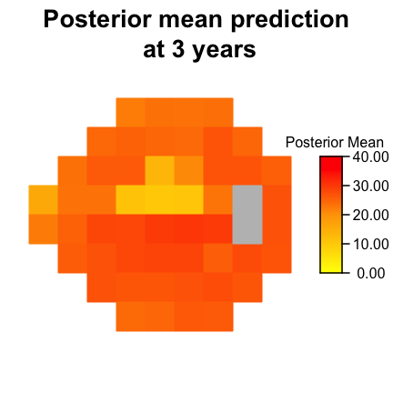

```r
PlotSensitivity(Y = apply(Predictions$Y$Y10, 2, mean) * 10,
                main = "Posterior mean prediction\n at 3 years",
                legend.lab = "Posterior Mean", legend.round = 2,
                bins = 250, border = FALSE, zlim = c(0, 40))
```

This figure shows the posterior predicted mean at 3 years over the visual field. The `PlotSensitivity` function can be used for plotting any observations on the visual field surface. We can also plot the standard deviation.

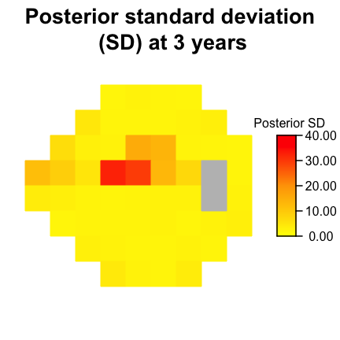

```r
PlotSensitivity(Y = apply(Predictions$Y$Y10 * 10, 2, sd),
                main = "Posterior standard deviation\n (SD) at 3 years",
                legend.lab = "Posterior SD", legend.round = 2,
                bins = 250, border = FALSE, zlim = c(0, 40))
```